# eMOLT Update

*eMOLT Update 2025-11-21*

## Weekly Recap

[figure not shown]

A huge thank you to all of the tech support partners who stepped up during the shutdown. Thanks to your efforts as well as the continuing improvements to system stability (thanks to Lowell Instruments and Ocean Data Network), thinks kept humming along pretty well while I was out. The only major hiccup has been adding new systems (new vessels, deckboxes, and sensors) to the system, but I took care of most of that backlog this week. To the captains who joined the program in October or early November, welcome, and I’m sorry for the delays getting your data and stipends processed. I expect the system to be fully up to date next week.

This week, the eMOLT fleet recorded 150 tows of sensorized fishing gear totaling 4272 sensor hours underwater.

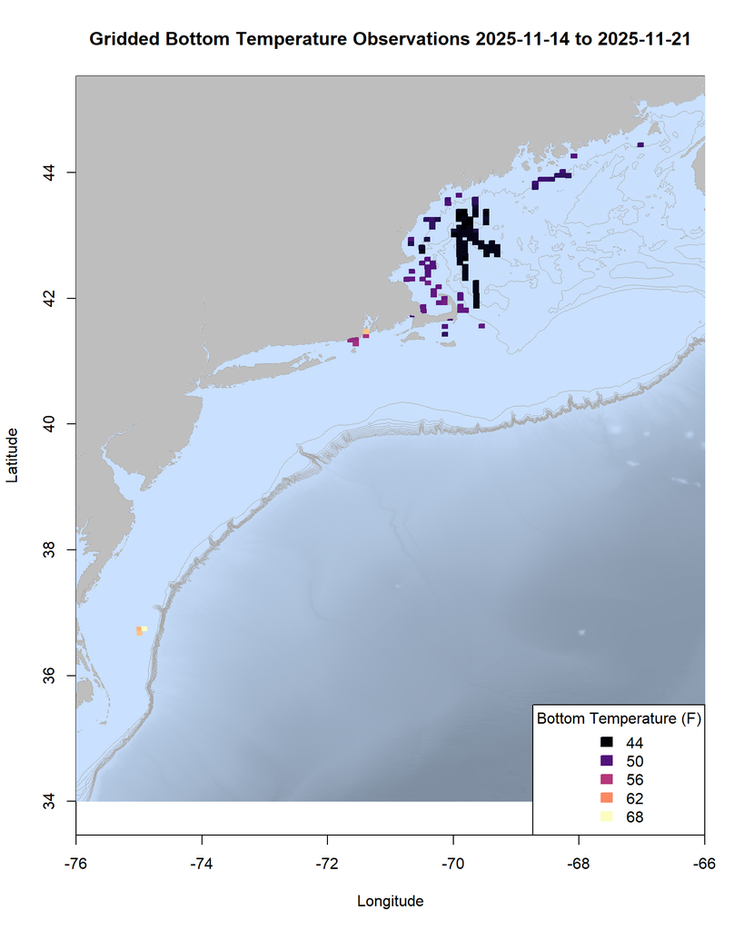

> *Figure 1 – FISHBOT bottom temperature records from the past week. The data are available on the [Commercial Fisheries Research Foundation ERDDAP](https://erddap.ondeckdata.com/erddap/tabledap/fishbot_realtime.html) and an interactive visualization is available at the [Cape Cod Ocean Watch](https://ccocean.whoi.edu/index.html) dashboard hosted by Woods Hole Oceanographic Institution. FISHBOT aggregates data provided by participants in eMOLT, the CFRF Lobster and Jonah Crab Research Fleet, the CFRF Shelf Research Fleet, the Cape Cod Commercial Fishermen’s Alliance Cape Cod Oceanographic Research Fleet, the Maine Coast Fishermen’s Association Fisheries Ocean Data Program, MassDMF Cape Cod Bay Study Fleet, the Northeast Fisheries Science Center Study Fleet, and the Northeast Fisheries Science Center Ecosystem Monitoring Surveys*

### Regional Dissolved Oxygen Loggers

Loggers deployed by fishermen along the Maine coast and the southern edge of Narragansett Bay showed normal levels of oxygen this past week, as did a logger deployed by Massachusetts Maritime Academy in Buzzards Bay.

### [Dissolved Oxygen in Cape Cod Bay](https://experience.arcgis.com/experience/0d553dfc6c60487cb1f4d20b5366ee0b/page/Map-Page/)

The seasonal threat of hypoxia has mostly abated in Cape Cod Bay. There was one very low reading northwest of Billingsgate earlier in the week, but subsequent readings looked normal. There are a few sites in the southwestern part of the bay with low DO still, but the number of loggers deployed and the fishing effort have both decreased from their late summer highs. Over the next few weeks, we’ll start collecting DO loggers from eMOLT participants so that we can move into our winter routine of cleaning, battery swaps, and calibration checks. This will be the last weekly update on seasonal hypoxia for the year.

[figure not shown]

> *Figure 2 – Dissolved oxygen observations from Cape Cod Bay collected by participants in the eMOLT program and the Cape Cod Bay Study Fleet program operated by Massachusetts Division of Marine Fisheries and the Massachusetts Lobstermen’s Association over the past week. Purple dots indicate dissolved oxygen values in the normal range (> 6 mg/L), yellow dots indicate low dissolved oxygen values (4-6 mg/L), orange dots indicate very low dissolved oxygen values (2-4 mg/L), and red dots indicate critically low values (< 2 mg/L).*

### Bottom Temperature Forecast Performance

This week, when compared with observations from the eMOLT program, NECOFS had a better R<sup>2</sup> value. This measures the “goodness of fit” or how close model predictions are to the actual data. NECOFS also had a lower Root Mean Squared Error and a lower bias indicating that when the model was off from the actual data it was less far off. This is visible in the map, where you can see lighter colors on the points (indicating smaller differences between forecast and observation) in the NECOFS comparison and darker colors (indicating a larger difference between forecast and observation) in the Doppio comparison. Observations were generally cooler than predicted by Doppio south of Cape Cod and warmer than predicted by Doppio north of Cape Cod. NECOFS performed well around Cape Cod. Observations east of Penobscot Bay were slightly warmer than predictions by both forecast models.

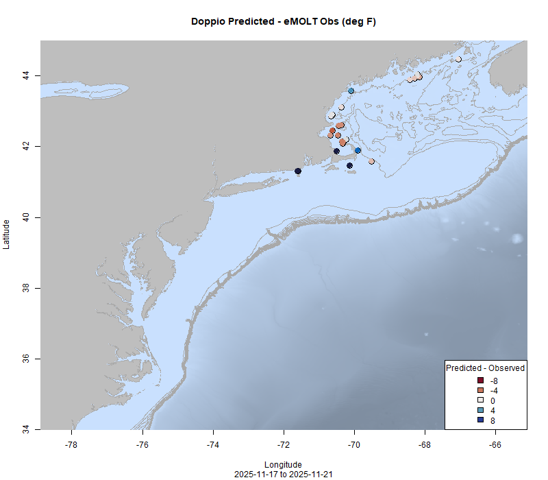

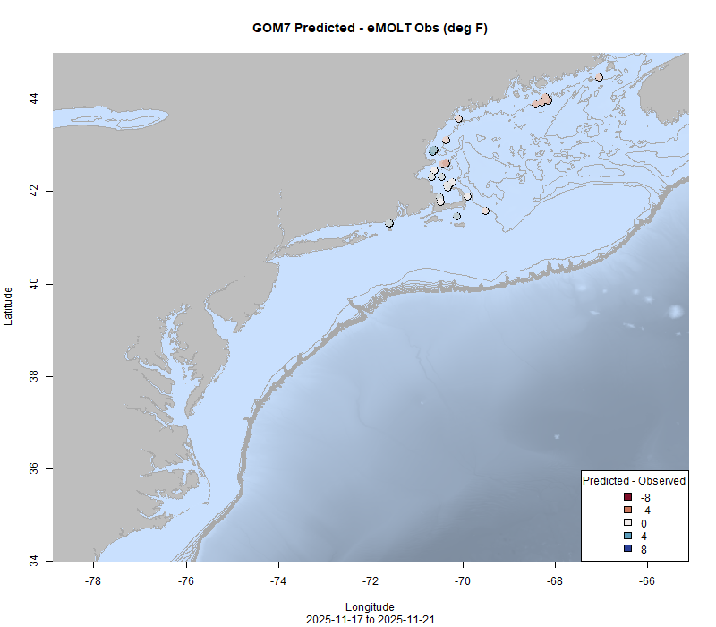

> *Figure 4 – Comparisons between bottom temperatures predicted by two ocean forecasting models and observations from the eMOLT fleet. Blue dots show where the observations were cooler than the forecast and red dots show where the observations were warmer than the forecast. White dots show areas where the observations and forecasts agreed. On the left is the comparison with the Doppio model and on the right is the comparison with the NECOFS model (GOM7).*

### Registration is open for the Northeast Cooperative Research Summit

[Registration](https://docs.google.com/forms/d/e/1FAIpQLSdEOiWo43NhsRpQHYecVgd6nBpvPHVAzztcH8XC2iXBKmKvyA/viewform) for the 2026 [Northeast Cooperative Research Summit](https://www.fisheries.noaa.gov/event/2026-northeast-cooperative-research-summit) on February 26, 2026 in Riverhead, New York is live! Everyone involved or interested in cooperative research is encouraged to attend, participate in breakout discussions and the research prioritization exercise, or contribute a presentation. Registration is open until November 30, 2025. Participation stipends are available for the first 30 on-the-water fishermen that register.

### Disclaimer

The eMOLT Update is NOT an official NOAA document. Mention of products or manufacturers does not constitute an endorsement by NOAA or Department of Commerce. The content of this update reflects only the personal views of the authors and does not necessarily represent the views of NOAA Fisheries, the Department of Commerce, or the United States.

All the best,

-George